# Como tratar Dados Faltantes no software R

Suzana de Lima

Junho, 2022

# Introdução

- “The best thing to do with missing values is not to have any”, Gertrude Mary Cox (1900 - 1978);

# Causas de dados faltantes.

- Dados perdidos;
- Falta ou omissão em respostas de questionários.

# Tipos de dados faltantes.

- MCAR: *Missing Completely at Random*, onde a falta de dados é totalmente aleatória;
- MNAR: *Missing Not at Random*, a falta de dados é correlacionada com características não observáveis;
- MAR: *Missing at Random*, os dados que estão faltando por razões relacionadas a variáveis completamente observadas no conjunto de dados.

# O que devemos fazer quando encontramos dados faltantes?

- Utilizar apenas aqueles casos com informações completas ou preencher com um valor plausível;
  - Análise de caso completo;
  - Substituir pela média/mediana;
  - Métodos baseados em modelos;
  - Imputação múltipla.

# Passos para a imputação múltipla.

- A ideia de imputação múltipla para dados perdidos foi proposta pela primeira vez por Rubin (1977), então propôs um procedimento de cinco etapas para imputar os dados perdidos:
  1. Imputar os valores perdidos usando um modelo apropriado que incorpore a variação aleatória;
  2. Repetir a primeira etapa 3-5 vezes;
  3. Realizar a análise desejada em cada conjunto de dados usando métodos de dados padrão e completos;
  4. Calcular a média dos valores das estimativas de parâmetros nas amostras de valores ausentes para obter uma estimativa de ponto único;
  5. Calcular os erros padrão pela média dos erros padrão quadrados das estimativas de valores ausentes.

# Pacotes que fazem imputação múltipla:

- MICE
- Amelia
- missForest
- Hmisc
- mi

# Pacote MICE

- Multivariate Imputation by Chained Equations
- Versão: 3.14.0
- O pacote contêm funções para três fases de imputação múltipla: **gerando de múltiplas imputações**, **Analisando dados imputados**, e **agrupando os resultados das análises**.

# Base de dados

- A base de dados **nhanes** contém dados de Schafer (1997, p. 237);
- O banco contém quatro variáveis:
  1. **age**: grupo de idade;
  2. **bmi**: índice de massa corporal;
  3. **hyp**: status de hipertensão;
  4. **chl**: nível de colesterol.

# Aplicação

- Pacotes utilizados

```r
require(mice)
require(VIM)
require(lattice)
require(broom)
require(kableExtra)
require(ggplot2)
```

- Base de dados

```r
df <- nhanes
head(df)
```

```
##   age  bmi hyp chl
## 1   1   NA  NA  NA
## 2   2 22.7   1 187
## 3   1   NA   1 187
## 4   3   NA  NA  NA
## 5   1 20.4   1 113
## 6   3   NA  NA 184
```

```r
str(df)
```

```
## 'data.frame':    25 obs. of  4 variables:
##  $ age: num  1 2 1 3 1 3 1 1 2 2 ...
##  $ bmi: num  NA 22.7 NA NA 20.4 NA 22.5 30.1 22 NA ...
##  $ hyp: num  NA 1 1 NA 1 NA 1 1 1 NA ...
##  $ chl: num  NA 187 187 NA 113 184 118 187 238 NA ...
```

- Processamento dos dados

```r
df$age <- as.factor(df$age)
```

- Inspecionando os dados faltantes

```r
apply(df,2, function(x) sum(is.na(x)))
```

```
## age bmi hyp chl
##   0   9   8  10
```

Utilizando o pacote *VIM*

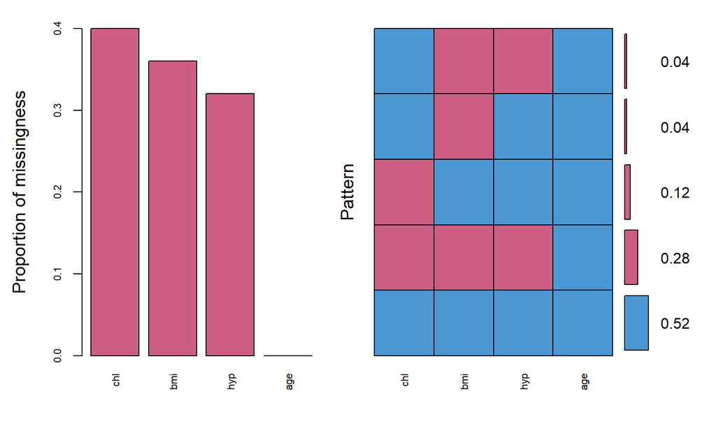

```
##
##  Variables sorted by number of missings:
##  Variable Count
##       chl  0.40
##       bmi  0.36
##       hyp  0.32
##       age  0.00
```

```r
coll <- c('#4C98D4','#CC5E85')

aggr_plot <- aggr(df, col= coll, numbers=TRUE, sortVars=TRUE, labels=names(data), cex.axis=.7, gap=3, ylab=c("Proportion of missingness","Pattern"))
```

- Verificando o padrão de dados faltantes

Utilizando o pacote *MICE*

```r
pares <- md.pairs(df)
```

As variáveis são observadas

```r
pares$rr
```

```
##     age bmi hyp chl
## age  25  16  17  15
## bmi  16  16  16  13
## hyp  17  16  17  14
## chl  15  13  14  15
```

A primeira variável é observada e a segunda é faltante

```r
pares$rm
```

```
##     age bmi hyp chl
## age   0   9   8  10
## bmi   0   0   0   3
## hyp   0   1   0   3
## chl   0   2   1   0
```

A primeira variável é faltante e a segunda é observada

```r
pares$mr
```

```
##     age bmi hyp chl
## age   0   0   0   0
## bmi   9   0   1   2
## hyp   8   0   0   1
## chl  10   3   3   0
```

As variáveis são faltantes

```r
pares$mm
```

```
##     age bmi hyp chl
## age   0   0   0   0
## bmi   0   9   8   7
## hyp   0   8   8   7
## chl   0   7   7  10
```

- Gráfico para análise bivariada de dados faltantes

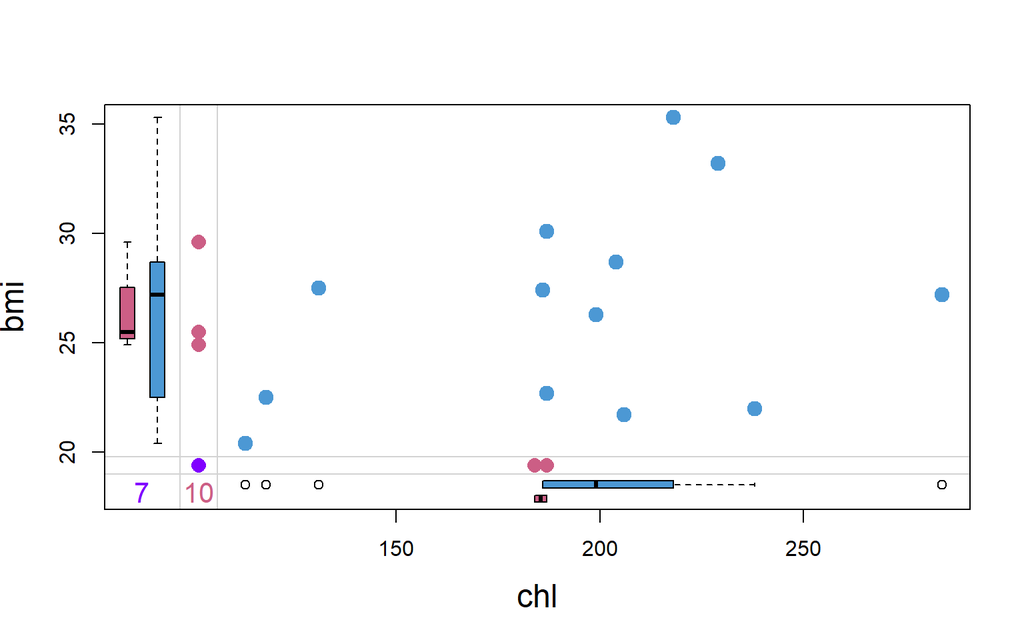

```r
color <- c('#4C98D4','#CC5E85','#8000FF' )
marginplot(nhanes[,c("chl","bmi")], col=color, cex=1.5,cex.lab= 1.5, cex.numbers= 1.3, pch=19)
```

- Modelo com dados completos

```
## [1] "Tamanho da base 25"
```

```
## [1] "Drop na da base 13"
```

```r
modc <- lm(chl ~ bmi+hyp+age, data = df)

kable(tidy(modc), "html", align = "c") %>%
  kable_styling(bootstrap_options = "striped")
```

| term | estimate | std.error | statistic | p.value |
| --- | --- | --- | --- | --- |
| (Intercept) | -27.984670 | 59.370110 | -0.4713596 | 0.6499709 |
| bmi | 7.160119 | 2.200899 | 3.2532707 | 0.0116439 |
| hyp | -7.692013 | 25.179480 | -0.3054874 | 0.7677926 |
| age2 | 59.543265 | 22.946889 | 2.5948295 | 0.0318729 |
| age3 | 109.457782 | 30.437329 | 3.5961690 | 0.0070213 |

- Análise de resíduo do modelo com dados completos

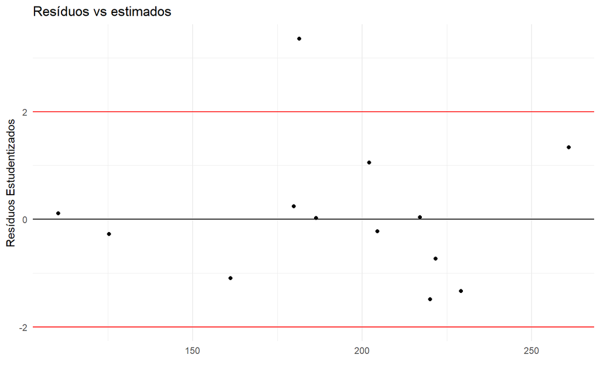

```r
ggplot(modc, aes(modc$fitted.values,rstudent(modc)))+
  geom_point()+
  theme(axis.text.x = element_text(size=10, angle=0), axis.text.y = element_text(options(scipen=9999),size=10, angle=0))+
  xlab("")+
  ylab("Resíduos Estudentizados")+
  labs(title="Resíduos vs estimados")+
  geom_hline(yintercept=0)+
  geom_hline(yintercept=2, color="red")+
  geom_hline(yintercept=-2, color="red")+
  theme_minimal()
```

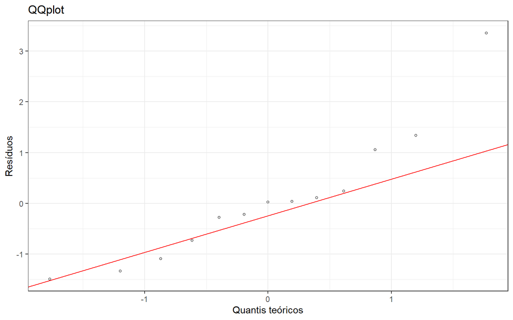

```r
ggQQ(modc)
```

- Criando imputações

```r
imp <- mice(df, printFlag = FALSE, maxit = 40, seed= 2022)
imp
```

```
## Class: mids
## Number of multiple imputations:  5
## Imputation methods:
##   age   bmi   hyp   chl
##    "" "pmm" "pmm" "pmm"
## PredictorMatrix:
##     age bmi hyp chl
## age   0   1   1   1
## bmi   1   0   1   1
## hyp   1   1   0   1
## chl   1   1   1   0
```

O método “**pmm**”, estima uma regressão linear com os casos completos e depois cria uma variabilidade aletória dos dados imputados a partir da distribuição posteriori preditiva de $\hat{\beta}$ para então produzir um novo conjunto de coeficientes $\beta^*$. Em seguida calcula os valores preditos para **Y**.

- Diagnóestico das imputações

```r
imp$imp$chl
```

```
##      1   2   3   4   5
## 1  118 204 218 229 131
## 4  186 206 206 187 204
## 10 199 229 187 131 229
## 11 187 187 199 206 187
## 12 204 204 199 229 184
## 15 187 187 187 238 131
## 16 118 131 187 184 238
## 20 218 131 186 218 199
## 21 118 187 187 199 187
## 24 284 206 204 187 218
```

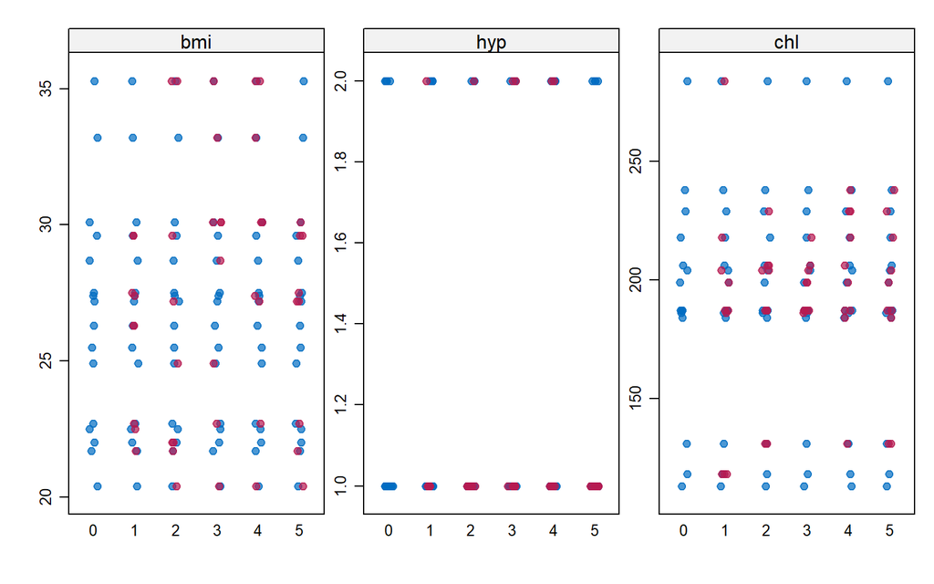

```r
stripplot(imp, pch = 20, cex = 1.2)
```

- Ajuste do modelo com dados imputados

```r
modci <- with(data=imp,exp= lm(chl ~ bmi+hyp+age))

combmod <- pool(modci)

summary(combmod)
```

```
##          term  estimate std.error  statistic       df    p.value
## 1 (Intercept) 19.816515 67.076565  0.2954313 7.918066 0.77526316
## 2         bmi  5.585439  2.530153  2.2075498 6.454844 0.06623662
## 3         hyp -6.860700 28.206350 -0.2432325 5.493337 0.81665039
## 4        age2 49.309554 29.089796  1.6950808 4.630681 0.15548553
## 5        age3 68.211389 33.350104  2.0453127 4.558875 0.10166954
```

- Dados completos vs Dados imputados

```r
summary(combmod)
```

```
##          term  estimate std.error  statistic       df    p.value
## 1 (Intercept) 19.816515 67.076565  0.2954313 7.918066 0.77526316
## 2         bmi  5.585439  2.530153  2.2075498 6.454844 0.06623662
## 3         hyp -6.860700 28.206350 -0.2432325 5.493337 0.81665039
## 4        age2 49.309554 29.089796  1.6950808 4.630681 0.15548553
## 5        age3 68.211389 33.350104  2.0453127 4.558875 0.10166954
```

```r
kable(tidy(modc), "html", align = "c") %>%
  kable_styling(bootstrap_options = "striped")
```

| term | estimate | std.error | statistic | p.value |
| --- | --- | --- | --- | --- |
| (Intercept) | -27.984670 | 59.370110 | -0.4713596 | 0.6499709 |
| bmi | 7.160119 | 2.200899 | 3.2532707 | 0.0116439 |
| hyp | -7.692013 | 25.179480 | -0.3054874 | 0.7677926 |
| age2 | 59.543265 | 22.946889 | 2.5948295 | 0.0318729 |
| age3 | 109.457782 | 30.437329 | 3.5961690 | 0.0070213 |

# Referências

- Van Buuren, S. and K. Groothuis-Oudshoorn, mice: Multivariate Imputation by Chained Equations in R. Journal of Statistical Software, 2011. 45(3): p. 67.
- [Multiple Imputation for Missing Data](https://www.statisticssolutions.com/dissertation-resources/multiple-imputation-for-missing-data/)
- [Getting Started with Multiple Imputation in R](https://data.library.virginia.edu/getting-started-with-multiple-imputation-in-r/#:~:text=Joint%20Multivariate%20Normal%20Distribution%20Multiple,values%20from%20this%20assumed%20distribution.)
- Vink, G., Frank, L. E., Pannekoek, J., and van Buuren, S. (2014). Predictive mean matching imputation of semicontinuous variables. Statistica Neerlandica. 68(1). 61-90.